# R Notebook

# Load data

I am using the AHA dataset for writing my code because it is the simplest dataset I can work with. Simplest = significant number of baseline samples without issue of repeated measures, balanced distribution of classes, likely difference to be detected present.

```r
c_ps = readRDS("/Users/aa370/Library/CloudStorage/Box-Box/project_davidlab/LAD_LAB_Personnel/Ammara_A/Projects/CHOICE/CHOICE_Trnl/CHOICE_20220912/ps_objects/choice_complete_20221205.rds")

c_ps
```

```
phyloseq-class experiment-level object
otu_table()   OTU Table:         [ 571 taxa and 259 samples ]
sample_data() Sample Data:       [ 259 samples by 22 sample variables ]
tax_table()   Taxonomy Table:    [ 571 taxa by 10 taxonomic ranks ]
```

```r
DSQ = read_csv("/Users/aa370/Library/CloudStorage/Box-Box/project_davidlab/LAD_LAB_Personnel/Ammara_A/Projects/CHOICE/Others_analysis/Tracy_analysis/CHOICE_ana_20220810_AA.csv")
dsq_filtered = DSQ %>%
  select(id = subj, bmi = bmi_child, age= age_child, gender = gender_child_f, ethnicity = eth_child_f, race = race_child_f, weight_change = child_weight_change)
```

```r
status = data.frame(true_week = c("EW1", "EW2", "W1", "W2", "W3", "W4", "W8"),
                    timepoint = c("Pre", "Pre", "Treatment", "Treatment", "Treatment", "Treatment", "Followup"))

dsq_id = dsq_filtered %>%
  pull(id)

sample_data(c_ps) =c_ps%>%
  sample_data() %>%
  as_tibble(rownames = NA) %>%
  rownames_to_column(var = "sample") %>%
  mutate(group = "Case") %>%
  left_join(status) %>%
  rename_all(tolower) %>%
  filter(id %in% dsq_id) %>%
  left_join(dsq_filtered) %>%
  column_to_rownames("sample")
proper_week = c("EW1", "EW2", "W1", "W2", "W3", "W4", "W8")

c_ps = c_ps %>%
  subset_samples(true_week %in% proper_week)
```

```r
rm(DSQ)
rm(dsq_filtered)
rm(dsq_id)
rm(proper_week)
rm(status)
```

# Preprocess

## Remove problematic samples

Taking out samples with less than or equal to 0 reads and keeping only treatment timepoint reduces samples from 259 down to 123.

```r
proper_week = c("W1", "W2", "W3", "W4", "W8")

c_ps = c_ps %>%
  subset_samples( reads > 0) %>%
  subset_samples(true_week %in% proper_week) %>%
  subset_samples(timepoint != "Pre")

sample_data(c_ps)
```

```
Sample Data:        [123 samples by 30 sample variables]:
```

|  | pcr_batch | pcr_date | type | order | cohort | aliquot | subj | week | true_week | id | sample_label | extraction_type | qubit | negative | qubit_converted | ng_added | seq_date | primer | template_volume | pcrb_cycles | reads | treatment | group | timepoint | bmi | age | gender | ethnicity | race | … |
| --- | --- | --- | --- | --- | --- | --- | --- | --- | --- | --- | --- | --- | --- | --- | --- | --- | --- | --- | --- | --- | --- | --- | --- | --- | --- | --- | --- | --- | --- | --- |
| 2-A06 | 2 | 9/20/22 | sample | 41 | CHOICE | C81W3 | C81 | W3 | W3 | 3PMV | TRUE | plate | 1.225 | 0 | 1.225 | 12.000000 | 11/28/22 | IDT SD | 3 | 10 | 43295 | Control | Case | Treatment | 26.0 | 9 | Female | Hispanic or Latino | Other | … |
| 2-A07 | 2 | 9/20/22 | sample | 49 | CHOICE | C63W2 | C63 | W2 | W2 | 6FYS | TRUE | plate | 0.854 | 0 | 0.854 | 12.000000 | 11/28/22 | IDT SD | 3 | 10 | 40015 | Control | Case | Treatment | 21.7 | 6 | Male | Not Hispanic or Latino | Black or African American | … |
| 2-A09 | 2 | 9/20/22 | sample | 65 | CHOICE | C79W1 | C79 | W1 | W1 | 2SRX | TRUE | plate | 0.954 | 0 | 0.954 | 12.000000 | 11/28/22 | IDT SD | 3 | 10 | 30430 | Intervention | Case | Treatment | 28.8 | 9 | Female | Not Hispanic or Latino | Black or African American | … |
| 2-A12 | 2 | 9/20/22 | sample | 89 | CHOICE | C37W3 | C37 | W3 | W3 | ZLYY | TRUE | plate | 0.700 | 0 | 0.700 | 12.000000 | 11/28/22 | IDT SD | 3 | 10 | 12516 | Control | Case | Treatment | 26.5 | 8 | Female | Not Hispanic or Latino | Black or African American | … |
| 2-B04 | 2 | 9/20/22 | sample | 26 | CHOICE | C109W2 | C109 | W2 | W2 | SP1H | TRUE | plate | 1.788 | 0 | 1.788 | 12.000000 | 11/28/22 | IDT SD | 3 | 10 | 58908 | Intervention | Case | Treatment | 32.3 | 10 | Female | Not Hispanic or Latino | White | … |
| 2-B06 | 2 | 9/20/22 | sample | 42 | CHOICE | C51W8 | C51 | W8 | W8 | 21BS | TRUE | plate | 0.716 | 0 | 0.716 | 12.000000 | 11/28/22 | IDT SD | 3 | 10 | 8023 | Control | Case | Followup | 29.5 | 10 | Female | Not Hispanic or Latino | Black or African American | … |
| 2-B07 | 2 | 9/20/22 | sample | 50 | CHOICE | C47W8 | C47 | W8 | W8 | KRSH | TRUE | plate | 1.953 | 0 | 1.953 | 12.000000 | 11/28/22 | IDT SD | 3 | 10 | 2619 | Control | Case | Followup | 34.8 | 6 | Male | Not Hispanic or Latino | Black or African American | … |
| 2-B08 | 2 | 9/20/22 | sample | 58 | CHOICE | C39W8 | C39 | W8 | W8 | RX6J | TRUE | plate | 0.857 | 0 | 0.857 | 12.000000 | 11/28/22 | IDT SD | 3 | 10 | 24384 | Intervention | Case | Followup | 36.4 | 9 | Male | Hispanic or Latino | White | … |
| 2-B10 | 2 | 9/20/22 | sample | 74 | CHOICE | C41W8 | C41 | W8 | W8 | MSV8 | TRUE | plate | 0.535 | 0 | 0.535 | 12.000000 | 11/28/22 | IDT SD | 3 | 10 | 37784 | Control | Case | Followup | 27.8 | 11 | Male | Hispanic or Latino | American Indian/Alaska Native | … |
| 2-B11 | 2 | 9/20/22 | sample | 82 | CHOICE | C57W1 | C57 | W1 | W1 | KQY2 | TRUE | plate | 1.105 | 0 | 1.105 | 12.000000 | 11/28/22 | IDT SD | 3 | 10 | 36096 | Intervention | Case | Treatment | 34.4 | 8 | Male | Hispanic or Latino | Other | … |

[output cut: 113 more lines]

Class distribution in this dataset: Control = 70 Intervention = 53

```r
sample_data(c_ps) %>%
  as.data.frame() %>%
  as_tibble() %>%
  group_by(treatment) %>%
  summarise(count = n())
```

| treatment | count |
| --- | --- |
| Control | 70 |
| Intervention | 53 |

## Data transform

```r
otu_clr = abundances(c_ps, "clr") %>% # rclr transform could not be performed, get Nans
  t()

c_ps = phyloseq(otu_table(otu_clr, taxa_are_rows = FALSE),
                   sample_data(sample_data(c_ps)),
                   tax_table(tax_table(c_ps)))

rm(otu_clr)
```

## Feature table

### Extract data

Order of asv colnames in OTU table and tax table is the same.

```r
features = c_ps@otu_table %>%
  as.data.frame() %>%
  as_tibble(rownames = NA) %>%
  rownames_to_column("sample")

feature_labels = c("sample")

 names = tax_table(c_ps) %>%
      data.frame() %>%
      lowest_level() %>%
   pull(name)

 feature_labels = append(feature_labels, names)

 feature_labels = make.unique(feature_labels) %>%
   make.names()

 colnames(features) = feature_labels

features
```

| sample | Rosaceae | Poaceae | Spinacia | Zea.mays | Apiaceae | Rosaceae.1 | Lactuca.sativa | Vitis | Theobroma.cacao | Musa | Fabaceae | Brassicaceae | Lauraceae | Sesamum.indicum | Apium.graveolens | Carya | Avena.sativa | Brassica.oleracea | Oryza.sativa | Phaseolus | Solanaceae | Capsicum | Ipomoea | Anacardium.occidentale | Linum.usitatissimum | Vaccinium | Salvia.hispanica | Coriandrum.sativum | Juglans | … |
| --- | --- | --- | --- | --- | --- | --- | --- | --- | --- | --- | --- | --- | --- | --- | --- | --- | --- | --- | --- | --- | --- | --- | --- | --- | --- | --- | --- | --- | --- | --- |
| 2-A06 | 9.98426789 | 6.87411966 | 6.31618816 | 10.98952042 | -0.12193004 | -0.12193004 | -0.12193004 | -0.12193004 | -0.12193004 | 4.99533938 | -0.12193004 | -0.12193004 | -0.12193004 | -0.12193004 | -0.12193004 | -0.12193004 | 4.80897652 | -0.12193004 | -0.12193004 | -0.12193004 | -0.12193004 | -0.12193004 | -0.12193004 | -0.12193004 | -0.12193004 | -0.12193004 | -0.12193004 | -0.12193004 | -0.12193004 | … |
| 2-A07 | -0.20864786 | 8.25524631 | 7.56877663 | 10.23732182 | 5.29145770 | -0.20864786 | 9.29671049 | -0.20864786 | 5.91232810 | -0.20864786 | 6.14331657 | -0.20864786 | 8.88385635 | -0.20864786 | -0.20864786 | -0.20864786 | 7.55278304 | -0.20864786 | -0.20864786 | 2.65716609 | 8.72179564 | -0.20864786 | -0.20864786 | -0.20864786 | -0.20864786 | -0.20864786 | -0.20864786 | 5.01474641 | -0.20864786 | … |
| 2-A09 | 6.27445477 | 8.65061442 | -0.14103754 | 6.86435642 | -0.14103754 | 10.70943662 | 9.84189057 | -0.14103754 | 5.58804070 | 8.99758843 | 7.06898286 | -0.14103754 | -0.14103754 | -0.14103754 | -0.14103754 | -0.14103754 | -0.14103754 | -0.14103754 | -0.14103754 | -0.14103754 | -0.14103754 | -0.14103754 | -0.14103754 | -0.14103754 | -0.14103754 | -0.14103754 | -0.14103754 | -0.14103754 | -0.14103754 | … |
| 2-A12 | 9.66671643 | 9.40081985 | -0.20471630 | 8.48291761 | 9.84340239 | 8.89307657 | 7.39600063 | 7.56330353 | 8.52350430 | 8.29662258 | -0.20471630 | -0.20471630 | -0.20471630 | -0.20471630 | -0.20471630 | -0.20471630 | -0.20471630 | -0.20471630 | 7.74913113 | -0.20471630 | -0.20471630 | -0.20471630 | -0.20471630 | -0.20471630 | -0.20471630 | -0.20471630 | -0.20471630 | -0.20471630 | -0.20471630 | … |
| 2-B04 | 6.10761024 | 5.78768337 | 11.15118180 | 7.03757063 | -0.22428595 | 2.99668196 | 3.45160378 | 2.93053620 | 6.01190743 | 6.27285332 | -0.22428595 | 4.46185446 | -0.22428595 | 3.66966908 | -0.22428595 | -0.22428595 | 4.47653392 | 4.62520787 | -0.22428595 | -0.22428595 | 3.66966908 | -0.22428595 | -0.22428595 | -0.22428595 | 5.03224732 | 5.24256290 | -0.22428595 | -0.22428595 | -0.22428595 | … |
| 2-B06 | -0.12719651 | 9.45865860 | -0.12719651 | -0.12719651 | 9.40597075 | -0.12719651 | -0.12719651 | -0.12719651 | -0.12719651 | -0.12719651 | -0.12719651 | -0.12719651 | -0.12719651 | 8.23398576 | -0.12719651 | -0.12719651 | -0.12719651 | -0.12719651 | -0.12719651 | -0.12719651 | -0.12719651 | 10.88331281 | -0.12719651 | -0.12719651 | -0.12719651 | -0.12719651 | -0.12719651 | -0.12719651 | -0.12719651 | … |
| 2-B07 | -0.09726373 | 11.01907259 | -0.09726373 | -0.09726373 | -0.09726373 | -0.09726373 | -0.09726373 | -0.09726373 | -0.09726373 | -0.09726373 | -0.09726373 | -0.09726373 | -0.09726373 | -0.09726373 | -0.09726373 | -0.09726373 | -0.09726373 | -0.09726373 | -0.09726373 | -0.09726373 | -0.09726373 | -0.09726373 | -0.09726373 | 9.37028316 | -0.09726373 | -0.09726373 | -0.09726373 | -0.09726373 | -0.09726373 | … |
| 2-B08 | -0.16402169 | 10.34202512 | -0.16402169 | 6.66789869 | -0.16402169 | 9.71340031 | 10.07617684 | -0.16402169 | 6.44185950 | 3.30969309 | 8.23688983 | 6.04495958 | -0.16402169 | -0.16402169 | -0.16402169 | -0.16402169 | -0.16402169 | -0.16402169 | -0.16402169 | -0.16402169 | -0.16402169 | -0.16402169 | -0.16402169 | -0.16402169 | -0.16402169 | -0.16402169 | -0.16402169 | -0.16402169 | -0.16402169 | … |
| 2-B10 | -0.17336488 | 5.26560094 | -0.17336488 | 9.81701931 | -0.17336488 | 10.07756847 | 8.52667007 | 9.96645166 | -0.17336488 | 2.87826562 | -0.17336488 | -0.17336488 | 8.57219030 | -0.17336488 | -0.17336488 | -0.17336488 | -0.17336488 | -0.17336488 | -0.17336488 | -0.17336488 | -0.17336488 | 6.47200065 | -0.17336488 | -0.17336488 | -0.17336488 | -0.17336488 | -0.17336488 | 7.63732510 | -0.17336488 | … |
| 2-B11 | 10.18591445 | 8.72997953 | -0.17653544 | 5.55182036 | 8.43671859 | 5.99002994 | 10.39629885 | 8.27730448 | 2.27168136 | -0.17653544 | -0.17653544 | -0.17653544 | -0.17653544 | -0.17653544 | -0.17653544 | -0.17653544 | -0.17653544 | -0.17653544 | -0.17653544 | -0.17653544 | -0.17653544 | -0.17653544 | -0.17653544 | -0.17653544 | 5.68063779 | 7.93175674 | -0.17653544 | -0.17653544 | -0.17653544 | … |

[output cut: 113 more lines]

### Attach data labels

```r
sample_labels = c_ps@sam_data%>%
  as.data.frame() %>%
  as_tibble(rownames = NA) %>%
  rownames_to_column("sample") %>%
  select(sample, id, treatment)

features = sample_labels %>%
  left_join(features) %>%
  select(-sample) %>%
  mutate(sample = id) %>%
  select(-id)
```

### Zero variance features

No features have zero variance

```r
nzv = features %>%
  select(!c(sample,treatment)) %>%
  nearZeroVar(saveMetrics = TRUE)
```

```r
rm(nzv)
```

### Correlated predictors

```r
feature_cor = features %>%
  select(!c(sample,treatment)) %>%
 cor()

summary(feature_cor[upper.tri(feature_cor)])
```

```
    Min.  1st Qu.   Median     Mean  3rd Qu.     Max.
-0.38913 -0.02774  0.02655  0.16971  0.17649  1.00000
```

```r
high_cor = findCorrelation(feature_cor, cutoff = .75)

filtered_features = features[,-high_cor]
```

```r
rm(high_cor)
rm(feature_cor)
```

### Linear dependencies

| treatment | Rosaceae | Poaceae | Spinacia | Zea.mays | Apiaceae | Rosaceae.1 | Lactuca.sativa | Vitis | Theobroma.cacao | Musa | Fabaceae | Brassicaceae | Lauraceae | Sesamum.indicum | Apium.graveolens | Carya | Avena.sativa | Brassica.oleracea | Oryza.sativa | Phaseolus | Solanaceae | Capsicum | Ipomoea | Anacardium.occidentale | Linum.usitatissimum | Vaccinium | Salvia.hispanica | Coriandrum.sativum | Juglans | … |
| --- | --- | --- | --- | --- | --- | --- | --- | --- | --- | --- | --- | --- | --- | --- | --- | --- | --- | --- | --- | --- | --- | --- | --- | --- | --- | --- | --- | --- | --- | --- |
| Control | 9.98426789 | 6.87411966 | 6.31618816 | 10.98952042 | -0.12193004 | -0.12193004 | -0.12193004 | -0.12193004 | -0.12193004 | 4.99533938 | -0.12193004 | -0.12193004 | -0.12193004 | -0.12193004 | -0.12193004 | -0.12193004 | 4.80897652 | -0.12193004 | -0.12193004 | -0.12193004 | -0.12193004 | -0.12193004 | -0.12193004 | -0.12193004 | -0.12193004 | -0.12193004 | -0.12193004 | -0.12193004 | -0.12193004 | … |
| Control | -0.20864786 | 8.25524631 | 7.56877663 | 10.23732182 | 5.29145770 | -0.20864786 | 9.29671049 | -0.20864786 | 5.91232810 | -0.20864786 | 6.14331657 | -0.20864786 | 8.88385635 | -0.20864786 | -0.20864786 | -0.20864786 | 7.55278304 | -0.20864786 | -0.20864786 | 2.65716609 | 8.72179564 | -0.20864786 | -0.20864786 | -0.20864786 | -0.20864786 | -0.20864786 | -0.20864786 | 5.01474641 | -0.20864786 | … |
| Intervention | 6.27445477 | 8.65061442 | -0.14103754 | 6.86435642 | -0.14103754 | 10.70943662 | 9.84189057 | -0.14103754 | 5.58804070 | 8.99758843 | 7.06898286 | -0.14103754 | -0.14103754 | -0.14103754 | -0.14103754 | -0.14103754 | -0.14103754 | -0.14103754 | -0.14103754 | -0.14103754 | -0.14103754 | -0.14103754 | -0.14103754 | -0.14103754 | -0.14103754 | -0.14103754 | -0.14103754 | -0.14103754 | -0.14103754 | … |
| Control | 9.66671643 | 9.40081985 | -0.20471630 | 8.48291761 | 9.84340239 | 8.89307657 | 7.39600063 | 7.56330353 | 8.52350430 | 8.29662258 | -0.20471630 | -0.20471630 | -0.20471630 | -0.20471630 | -0.20471630 | -0.20471630 | -0.20471630 | -0.20471630 | 7.74913113 | -0.20471630 | -0.20471630 | -0.20471630 | -0.20471630 | -0.20471630 | -0.20471630 | -0.20471630 | -0.20471630 | -0.20471630 | -0.20471630 | … |
| Intervention | 6.10761024 | 5.78768337 | 11.15118180 | 7.03757063 | -0.22428595 | 2.99668196 | 3.45160378 | 2.93053620 | 6.01190743 | 6.27285332 | -0.22428595 | 4.46185446 | -0.22428595 | 3.66966908 | -0.22428595 | -0.22428595 | 4.47653392 | 4.62520787 | -0.22428595 | -0.22428595 | 3.66966908 | -0.22428595 | -0.22428595 | -0.22428595 | 5.03224732 | 5.24256290 | -0.22428595 | -0.22428595 | -0.22428595 | … |
| Control | -0.12719651 | 9.45865860 | -0.12719651 | -0.12719651 | 9.40597075 | -0.12719651 | -0.12719651 | -0.12719651 | -0.12719651 | -0.12719651 | -0.12719651 | -0.12719651 | -0.12719651 | 8.23398576 | -0.12719651 | -0.12719651 | -0.12719651 | -0.12719651 | -0.12719651 | -0.12719651 | -0.12719651 | 10.88331281 | -0.12719651 | -0.12719651 | -0.12719651 | -0.12719651 | -0.12719651 | -0.12719651 | -0.12719651 | … |
| Control | -0.09726373 | 11.01907259 | -0.09726373 | -0.09726373 | -0.09726373 | -0.09726373 | -0.09726373 | -0.09726373 | -0.09726373 | -0.09726373 | -0.09726373 | -0.09726373 | -0.09726373 | -0.09726373 | -0.09726373 | -0.09726373 | -0.09726373 | -0.09726373 | -0.09726373 | -0.09726373 | -0.09726373 | -0.09726373 | -0.09726373 | 9.37028316 | -0.09726373 | -0.09726373 | -0.09726373 | -0.09726373 | -0.09726373 | … |
| Intervention | -0.16402169 | 10.34202512 | -0.16402169 | 6.66789869 | -0.16402169 | 9.71340031 | 10.07617684 | -0.16402169 | 6.44185950 | 3.30969309 | 8.23688983 | 6.04495958 | -0.16402169 | -0.16402169 | -0.16402169 | -0.16402169 | -0.16402169 | -0.16402169 | -0.16402169 | -0.16402169 | -0.16402169 | -0.16402169 | -0.16402169 | -0.16402169 | -0.16402169 | -0.16402169 | -0.16402169 | -0.16402169 | -0.16402169 | … |
| Control | -0.17336488 | 5.26560094 | -0.17336488 | 9.81701931 | -0.17336488 | 10.07756847 | 8.52667007 | 9.96645166 | -0.17336488 | 2.87826562 | -0.17336488 | -0.17336488 | 8.57219030 | -0.17336488 | -0.17336488 | -0.17336488 | -0.17336488 | -0.17336488 | -0.17336488 | -0.17336488 | -0.17336488 | 6.47200065 | -0.17336488 | -0.17336488 | -0.17336488 | -0.17336488 | -0.17336488 | 7.63732510 | -0.17336488 | … |
| Intervention | 10.18591445 | 8.72997953 | -0.17653544 | 5.55182036 | 8.43671859 | 5.99002994 | 10.39629885 | 8.27730448 | 2.27168136 | -0.17653544 | -0.17653544 | -0.17653544 | -0.17653544 | -0.17653544 | -0.17653544 | -0.17653544 | -0.17653544 | -0.17653544 | -0.17653544 | -0.17653544 | -0.17653544 | -0.17653544 | -0.17653544 | -0.17653544 | 5.68063779 | 7.93175674 | -0.17653544 | -0.17653544 | -0.17653544 | … |

[output cut: 113 more lines]

## Input table

Preprocessing reduces column number to 125 from 571

```r
input = filtered_features %>%
  mutate(treatment_shuffle = sample(treatment) %>%
           as.factor(),
         treatment = as.factor(treatment))
```

# Modeling

Load functions from classification_function_AA file

```r
label_list = c("treatment", "treatment_shuffle")
results = loop_label(iterations =20, input, label_list, percent = 0.8, repeated_measures = TRUE)
```

```
[1] "initiating repeated measures protocol"
[1] "running repeated measures model loop"
```

```r
rm(label_list)
```

The version splitting such that there is no id overlap between test and train and using group_K_fold performs very weirdly. Sometimes no difference between treatment and shuffled but seems to be a trend for shuffled and shuffled definitely higher once.

The version with regular splitting performs like expected. Probably because of the information sharing between the samples but need to look into further to confirm what is happening.

# Plotting

## AUC plot and t-test

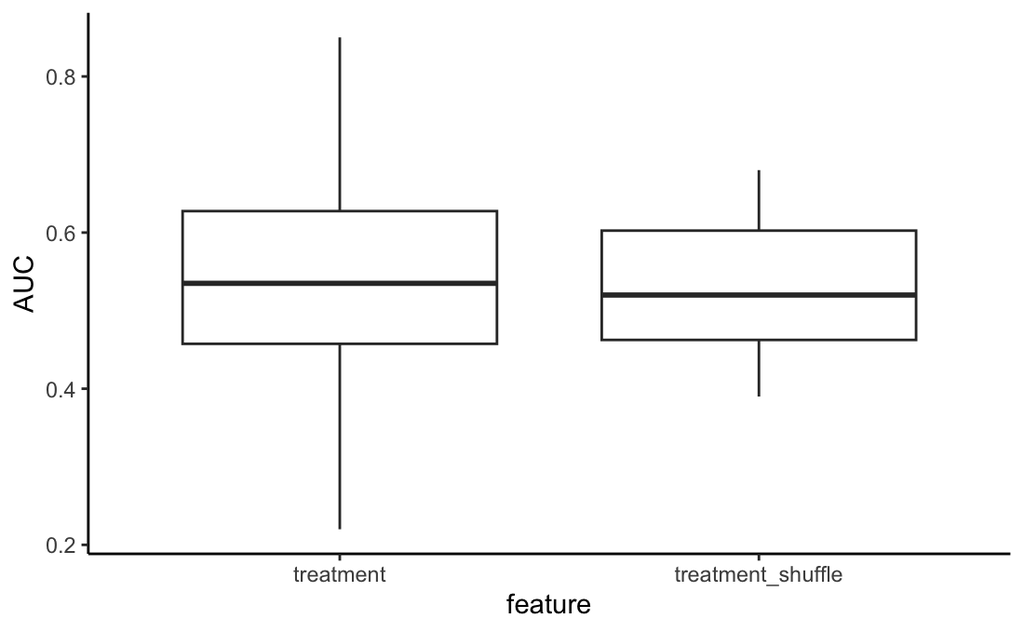

```r
auc_df %>%
  pivot_longer(cols = c("treatment", "treatment_shuffle"), names_to = "feature", values_to = "AUC") %>%
  ggplot()+
  geom_boxplot(aes(x=feature, y = AUC))+
  theme_classic()
```

```r
t.test(auc_df$treatment, auc_df$treatment_shuffle)
```

```
    Welch Two Sample t-test

data:  auc_df$treatment and auc_df$treatment_shuffle
t = 0.56031, df = 30.585, p-value = 0.5793
alternative hypothesis: true difference in means is not equal to 0
95 percent confidence interval:
 -0.0607655  0.1067655
sample estimates:
mean of x mean of y
    0.551     0.528
```

## Importance plots

### look-up table

```r
#Making asv reference for names in model
lookup_asv = tax_table(c_ps) %>%
     data.frame() %>%
      lowest_level() %>%
   rownames_to_column("asv") %>%
   select(asv, name) %>%
   mutate(name = make.names(make.unique(name)))
```

### summarize importances

```r
# Making summary df of importances
importance_summary = importance_df %>%
  pivot_longer(cols = c("Sesamum.indicum":"NA.52"), names_to = "food", values_to = "importance") %>%
  group_by(variable, food) %>%
  summarise(mean_importance = mean(importance)) %>%
  arrange(variable, desc(mean_importance))
```

### top 10 ranked list

```r
top10
```

```
 [1] "NA."                  "Solanum.lycopersicum" "NA.5"
 [4] "Fabaceae"             "Spinacia"             "Poaceae"
 [7] "Vaccinium"            "Rosaceae.1"           "Phaseolus"
[10] "NA.23"
```

### Importance plot

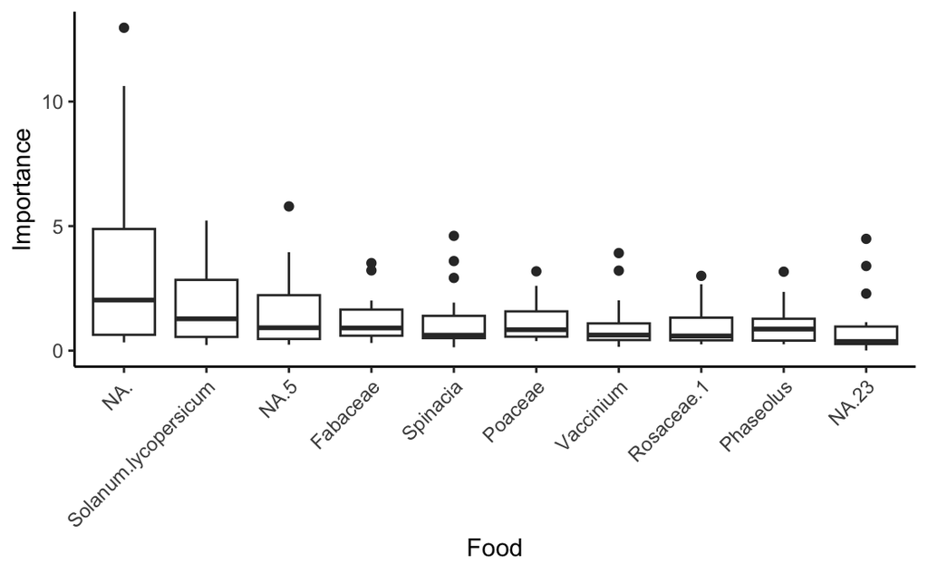

```r
importance_df %>%
  pivot_longer(cols = c("Sesamum.indicum":"NA.52"), names_to = "food", values_to = "importance")  %>%
  filter(variable == "treatment" & food %in% top10) %>%
  ggplot()+
  geom_boxplot(aes(x= reorder(food,-importance), y = importance))+
  labs(x= "Food", y ="Importance") +
  theme_classic() +
  theme(axis.text.x = element_text(angle = 45, hjust=1))
```

Some of the important NAs for predictions only map to bacterial species in BLAST.

# Important taxa directions

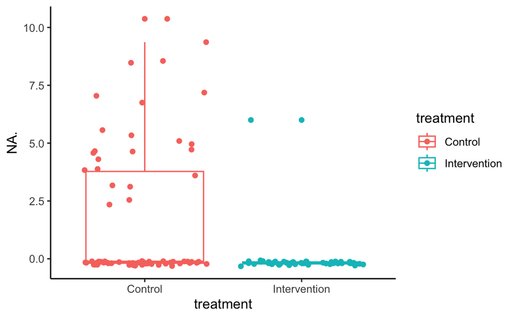

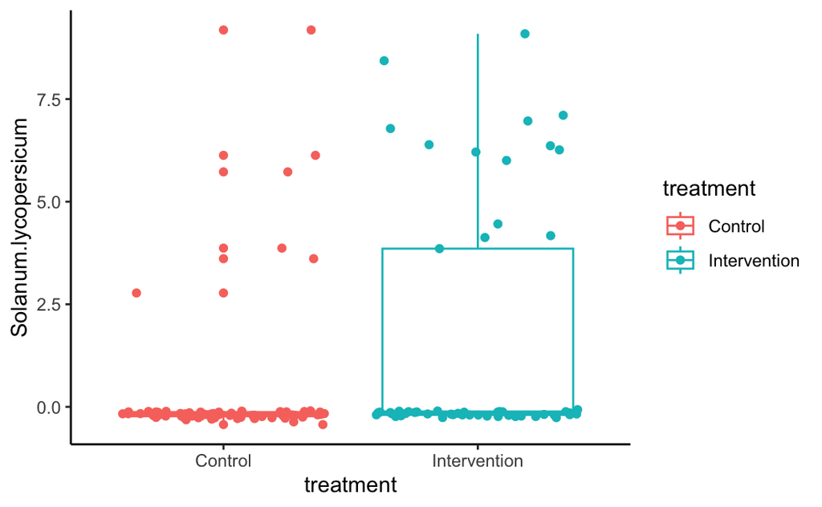

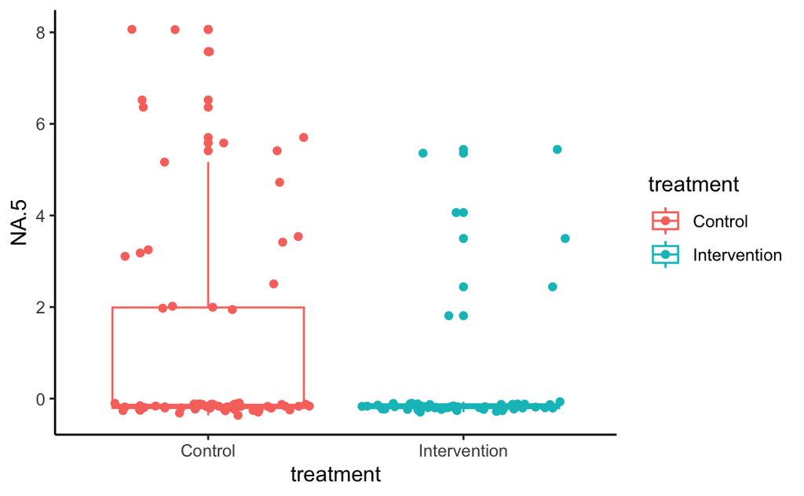

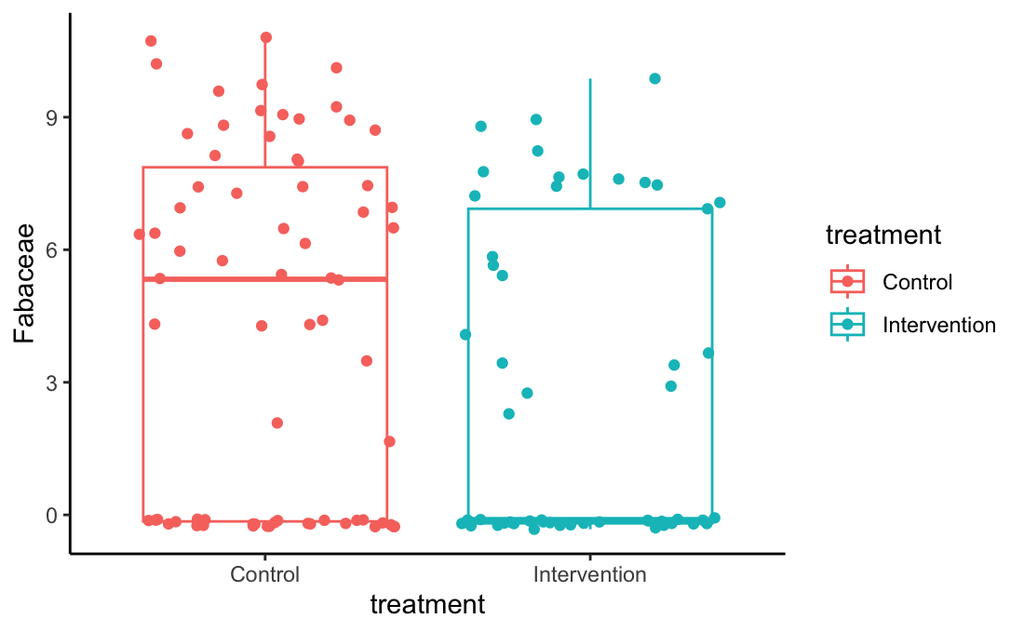

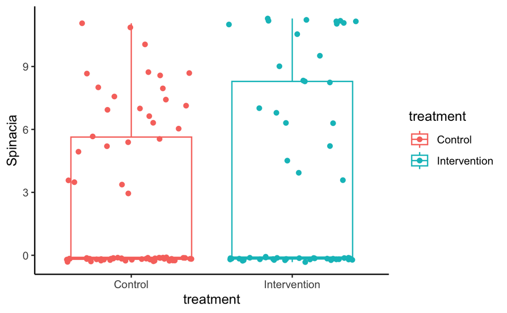

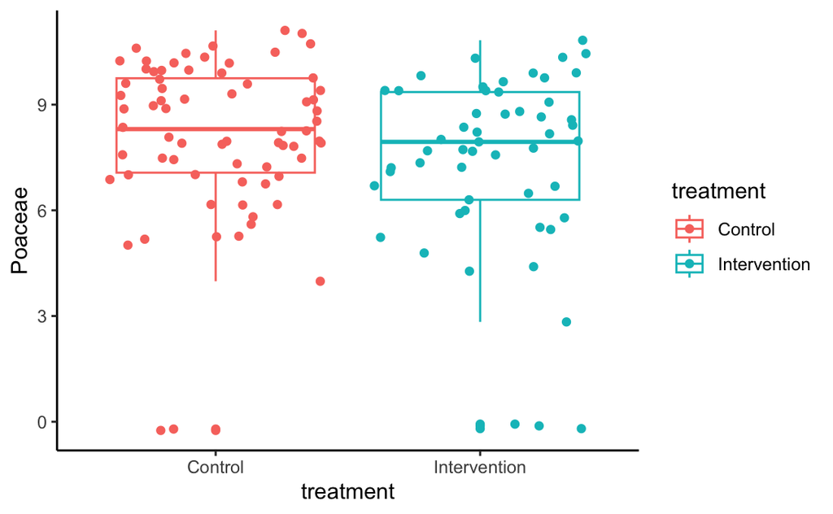

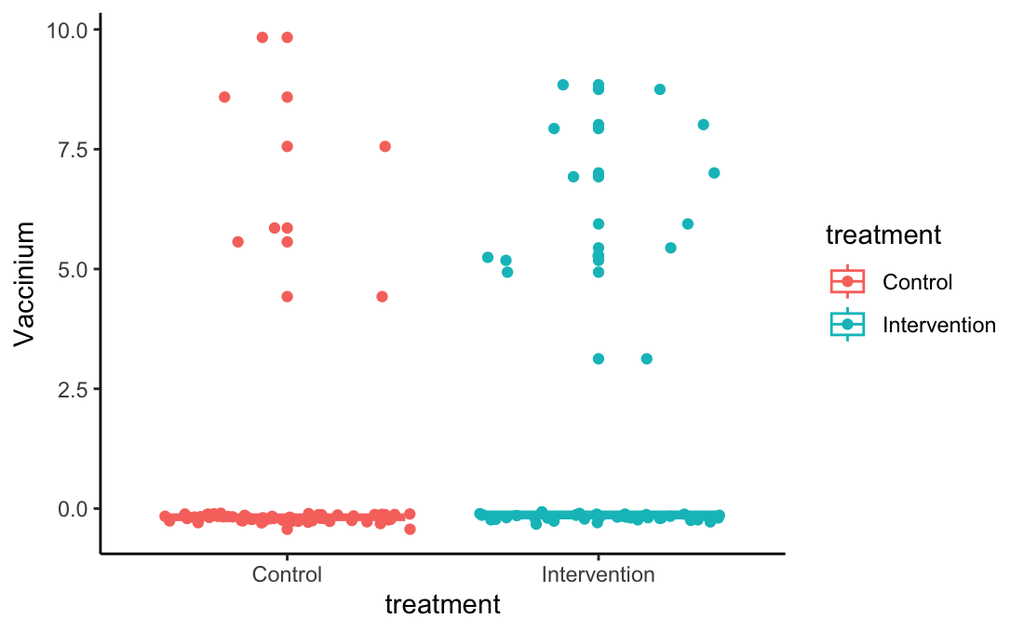

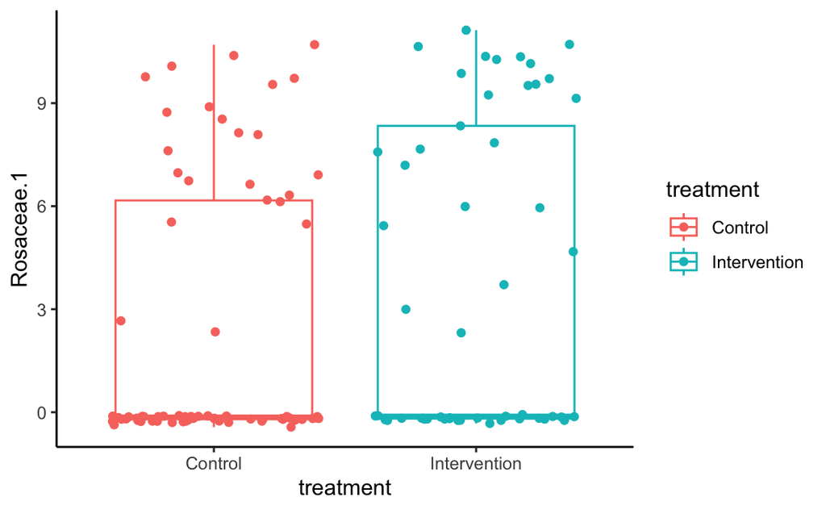

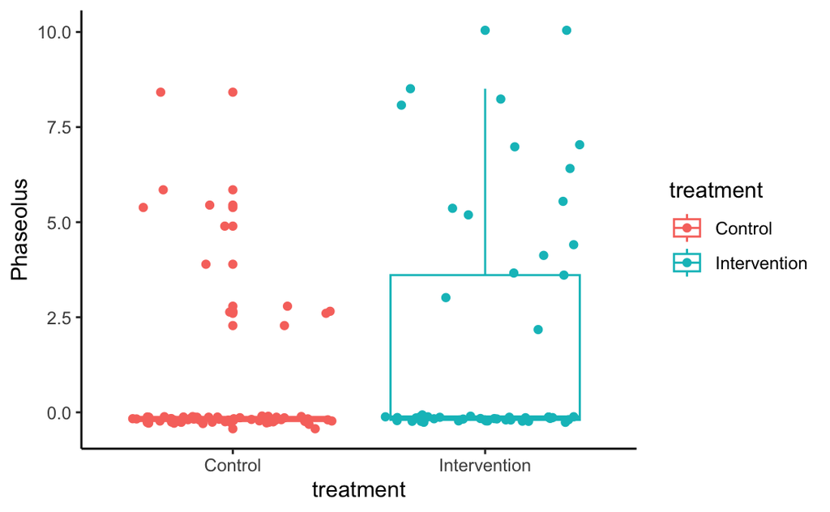

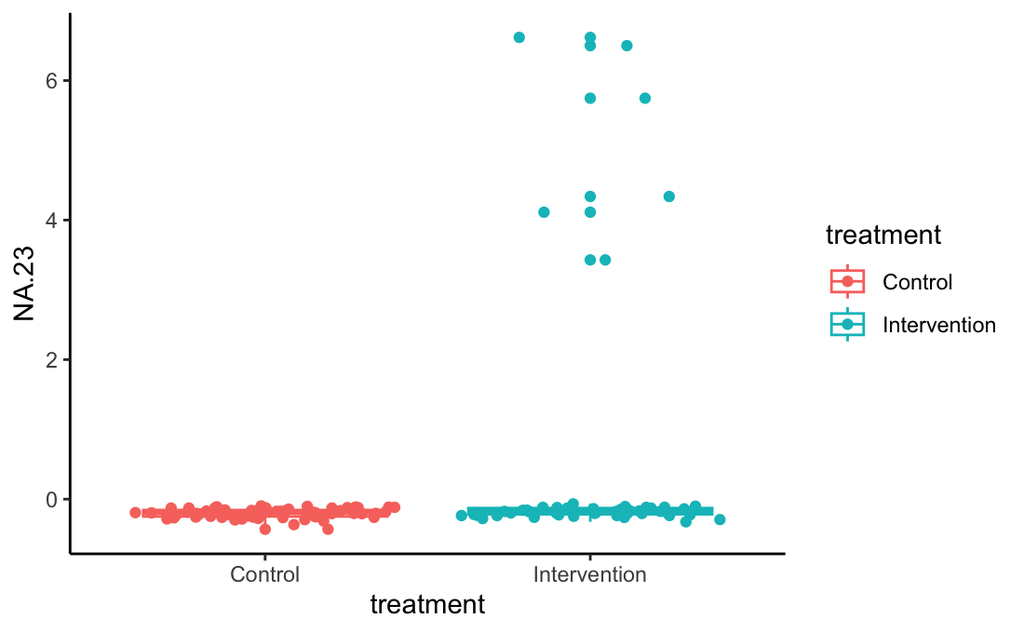

```r
plot_food_direction(top10, input, variable = "treatment")
```

```r
lookup_asv %>%
  filter(name == "Fabaceae") %>%
  pull(asv)
```

```
[1] "ATCCTGTTTTCCGAAAACAAAGAAAAGTTCATAAAGTGATAATAAAAAAGG"
```

```r
feature_cor %>%
  as.data.frame() %>%
  select(Helianthus.annuus) %>%
  arrange(desc(Helianthus.annuus))
```